# Plantilla Modelado y evaluación de los datos — Redes Neuronales (MLP)

**Objetivo:** Construir, entrenar e interpretar un modelo de Red Neuronal (Perceptrón Multicapa) utilizando los datos preparados, y evaluar su desempeño para compararlo con otras alternativas.

> Para cada subsección encontrarás una celda *Markdown* con instrucciones y una celda de *Python* para tu código.

```python
import numpy as np
import pandas as pd
import matplotlib.pyplot as plt
import seaborn as sns

# Selección y validación de modelos
from sklearn.model_selection import train_test_split, cross_val_score, StratifiedKFold, GridSearchCV, RandomizedSearchCV

# Preprocesamiento: estandarización (necesaria para redes neuronales)
from sklearn.preprocessing import StandardScaler

# Métricas estrictamente para clasificación
from sklearn.metrics import accuracy_score, precision_score, recall_score, f1_score, roc_auc_score, confusion_matrix, roc_curve

# Interpretación de modelos sin importancia de variables nativa (como el MLP)
from sklearn.inspection import permutation_importance

# Modelos de clasificación
from sklearn.svm import SVC                           # Máquinas de Vectores de Soporte
from sklearn.neural_network import MLPClassifier      # Redes neuronales (Perceptrón Multicapa)
```

## 1. Selección del tipo de modelo

- Determinar si el problema es de clasificación, regresión o agrupamiento.
- Elegir los algoritmos adecuados según el tipo de problema y la naturaleza de los datos. Ejemplos:
  - Clasificación: Regresión logística, Árboles de decisión, Random Forest, SVM, Redes neuronales.
  - Regresión: Regresión lineal, Random Forest Regressor, XGBoost, Redes neuronales.
  - Agrupamiento: K-Means, DBSCAN, Hierarchical Clustering

Después de un proceso de análisis en grupo, hemos determinado que nuestro reto del Spaceship Titan es un problema de clasificación binaria supervisada porque la variable objetivo **transported**, es categórica booleana y busca determinar a que categoría pertenece cada pasajero. Consideramos que es un reto de supervisión porque contamos con el conjunto de datos de entrenamiento que contiene ya la variable respuesta conocida para entrenar el modelo.

Por último, es binaria dado a que lo que nuestros modelos buscarán predecir es ver si es verdadero o falso la variable objetivo.

Exploramos una **Red Neuronal Artificial (Perceptrón Multicapa, MLP)** como alternativa a Random Forest. A diferencia de un modelo basado en árboles, un MLP aprende la relación entre las variables predictoras y la variable objetivo mediante capas de neuronas conectadas por pesos, ajustados iterativamente por **descenso de gradiente** y **retropropagación del error (backpropagation)**. Cada neurona aplica una transformación afín seguida de una función de activación no lineal (por ejemplo, ReLU), lo que permite a la red aproximar relaciones no lineales entre las variables sin que tengamos que definirlas explícitamente.

## 2. Separación de los conjuntos de datos

- Confirma la **separación train/test** (y opcionalmente *validation*).
- Asegura **reproducibilidad** (semilla aleatoria).

```python
# Escribe tu código aquí

# Se cargan los datos
df = pd.read_csv("data_for_modeling.csv")
df_limpio = df.copy()

# Separar variables predictoras (X) y objetivo (y)
X = df_limpio.drop('Transported', axis=1)
y = df_limpio['Transported'].astype(int)

# Al definir random_state=42, garantizamos que el corte de datos sea siempre igual.
# stratify=y asegura que la proporción de clases se mantenga en Train y Test.
X_train, X_test, y_train, y_test = train_test_split(
    X, y,
    test_size=0.2,
    random_state=42,
    stratify=y
)

scaler = StandardScaler()

# Ajustar el escale para los datos de train
X_train= scaler.fit_transform(X_train)

# Aplicar la misma transformación al test
X_test = scaler.transform(X_test)


# Se confirma separación de separación entre Train y Test
print("--- Confirmación de la Separación Train/Test ---")
print(f"Total de datos disponibles: {len(X)} registros")
print(f"Conjunto de Entrenamiento (Train): {len(X_train)} registros ({len(X_train)/len(X):.1%})")
print(f"Conjunto de Prueba (Test): {len(X_test)} registros ({len(X_test)/len(X):.1%})")

print("\nEquilibrio de clases ('Transported') en Entrenamiento:")
print(y_train.value_counts(normalize=True).round(4))

print("\nEquilibrio de clases ('Transported') en Prueba:")
print(y_test.value_counts(normalize=True).round(4))
```

```
--- Confirmación de la Separación Train/Test ---
Total de datos disponibles: 8693 registros
Conjunto de Entrenamiento (Train): 6954 registros (80.0%)
Conjunto de Prueba (Test): 1739 registros (20.0%)

Equilibrio de clases ('Transported') en Entrenamiento:
Transported
1    0.5036
0    0.4964
Name: proportion, dtype: float64

Equilibrio de clases ('Transported') en Prueba:
Transported
1    0.5037
0    0.4963
Name: proportion, dtype: float64
```

## 3. Entrenamiento del modelo

- Ajustar el modelo a los datos de entrenamiento mediante el método fit().
- Controlar el proceso con métricas de entrenamiento (por ejemplo, accuracy, pérdida, etc.).
- Guardar los parámetros y configuraciones del modelo

```python
import joblib

# Inicializar el modelo con semilla aleatoria
# Arquitectura base: dos capas ocultas de 50 neuronas cada una, activación ReLU (estándar
# para MLP) y hasta 500 iteraciones del optimizador para dar margen a la convergencia.
modelo_mlp = MLPClassifier(
    hidden_layer_sizes=(50, 50),
    activation='relu',
    max_iter=500,
    random_state=42
)

# Ajustar el modelo a los datos de entrenamiento mediante fit()
print("Entrenando el modelo de Red Neuronal (MLP)...")
modelo_mlp.fit(X_train, y_train)

# Controlar el proceso con métricas de entrenamiento
y_pred_train_mlp = modelo_mlp.predict(X_train)
accuracy_train_mlp = accuracy_score(y_train, y_pred_train_mlp)

print("\n--- Métricas de Entrenamiento ---")
print(f"Exactitud (Accuracy) en Train: {accuracy_train_mlp:.4f}")
print(f"Número de iteraciones hasta la convergencia: {modelo_mlp.n_iter_}")
print(f"Valor final de la función de pérdida (loss): {modelo_mlp.loss_:.4f}")

# Guardar los parámetros y configuraciones del modelo
print("\n--- Parámetros del Modelo ---")
parametros = modelo_mlp.get_params()
for param, valor in parametros.items():
    print(f"{param}: {valor}")

# Guardar el modelo entrenado en un archivo para su uso posterior
archivo_modelo = 'modelo_red_neuronal_base.pkl'
joblib.dump(modelo_mlp, archivo_modelo)
print(f"\n¡Modelo y configuraciones guardados exitosamente en '{archivo_modelo}'!")
```

[output not shown]

```
Entrenando el modelo de Red Neuronal (MLP)...
```

## 4. Validación y ajuste de hiperparámetros

- Aplicar técnicas de validación cruzada (cross-validation) para medir la robustez del modelo.
- Utilizar métodos de optimización de hiperparámetros:
  - Grid Search
  - Random Search
  - Bayesian Optimization o frameworks como Optuna.
- Ajustar los parámetros que maximizan el desempeño del modelo.

```python
from sklearn.model_selection import cross_val_score, GridSearchCV
import joblib

# Validación Cruzada del modelo base
print("Aplicando Validación Cruzada a la Red Neuronal base...")

# n_jobs=-1 permite usar todos los núcleos de la computadora para acelerar el proceso
puntuaciones_cv_mlp = cross_val_score(modelo_mlp, X_train, y_train, cv=5, scoring='accuracy', n_jobs=-1)

print(f"Exactitud en cada partición: {puntuaciones_cv_mlp}")
print(f"Exactitud Media (Base): {puntuaciones_cv_mlp.mean():.4f}")
print(f"Desviación Estándar: {puntuaciones_cv_mlp.std():.4f}")

# Ajuste de Hiperparámetros con Grid Search
print("\nIniciando Grid Search para optimización de hiperparámetros...")

# Definimos el grid específico para el Perceptrón Multicapa
parametros_grid_mlp = {
    'hidden_layer_sizes': [(50,), (50, 50), (100,), (100, 50)],  # 4 opciones
    'activation': ['relu', 'tanh'],                              # 2 opciones
    'alpha': [0.0001, 0.001, 0.01],                              # 3 opciones
    'learning_rate_init': [0.001, 0.01],                         # 2 opciones
}

# Configurar el GridSearchCV
grid_search_mlp = GridSearchCV(
    estimator=MLPClassifier(max_iter=500, random_state=42),
    param_grid=parametros_grid_mlp,
    cv=5,
    scoring='accuracy',
    n_jobs=-1,
    verbose=1 # Mostrará el progreso
)

# Entrenar el Grid Search
grid_search_mlp.fit(X_train, y_train)

# Guardar el modelo optimizado
mejor_modelo_mlp = grid_search_mlp.best_estimator_
joblib.dump(mejor_modelo_mlp, 'mejor_modelo_red_neuronal.pkl')

print("\n--- Resultados de la Optimización ---")
print(f"Mejores Parámetros Encontrados: {grid_search_mlp.best_params_}")
print(f"Mejor Exactitud durante Validación Cruzada: {grid_search_mlp.best_score_:.4f}")
```

```
Aplicando Validación Cruzada a la Red Neuronal base...
Exactitud en cada partición: [0.79007908 0.77066858 0.78073329 0.77929547 0.78633094]
Exactitud Media (Base): 0.7814
Desviación Estándar: 0.0066

Iniciando Grid Search para optimización de hiperparámetros...
Fitting 5 folds for each of 48 candidates, totalling 240 fits

--- Resultados de la Optimización ---
Mejores Parámetros Encontrados: {'activation': 'relu', 'alpha': 0.001, 'hidden_layer_sizes': (50,), 'learning_rate_init': 0.001}
Mejor Exactitud durante Validación Cruzada: 0.8037
```

## 5. Evaluación del modelo

- Evalúa en **X_test, y_test** con métricas adecuadas:
  - Clasificación: *accuracy*, *precision*, *recall*, *F1*, **ROC-AUC**, matriz de confusión.
  - Regresión: **MAE**, **RMSE**, **R²**.
  - Agrupamiento: **Silhouette Score**, **Davies–Bouldin**.
- Analiza **sesgo y varianza** (under/overfitting).

```
--- Evaluación en Conjunto de Prueba (Red Neuronal Optimizada) ---
Accuracy:  0.8131
Precision: 0.8284
Recall:    0.7934
F1-Score:  0.8105
ROC-AUC:   0.8988

--- Análisis de Sesgo y Varianza ---
Rendimiento en Entrenamiento (Train): 0.8428
Rendimiento en Prueba (Test):         0.8131
Diferencia (Train - Test):            0.0297

Diagnóstico: BALANCE ADECUADO. El modelo generaliza de forma excelente.
```

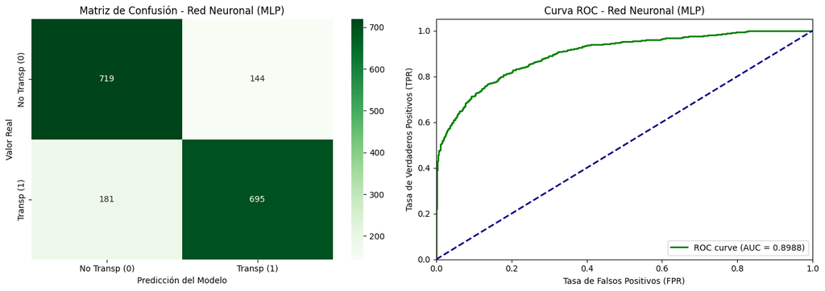

```python
from sklearn.metrics import accuracy_score, precision_score, recall_score, f1_score, roc_auc_score, confusion_matrix, roc_curve
import matplotlib.pyplot as plt
import seaborn as sns

# Generar predicciones y probabilidades para Train y Test
y_pred_train_mlp = mejor_modelo_mlp.predict(X_train)
y_pred_test_mlp = mejor_modelo_mlp.predict(X_test)

# predict_proba para la Curva ROC (probabilidad de ser clase 1)
y_prob_train_mlp = mejor_modelo_mlp.predict_proba(X_train)[:, 1]
y_prob_test_mlp = mejor_modelo_mlp.predict_proba(X_test)[:, 1]

# Cálculo de métricas principales en Test
acc_mlp = accuracy_score(y_test, y_pred_test_mlp)
prec_mlp = precision_score(y_test, y_pred_test_mlp)
rec_mlp = recall_score(y_test, y_pred_test_mlp)
f1_mlp = f1_score(y_test, y_pred_test_mlp)
roc_auc_mlp = roc_auc_score(y_test, y_prob_test_mlp)

print("--- Evaluación en Conjunto de Prueba (Red Neuronal Optimizada) ---")
print(f"Accuracy:  {acc_mlp:.4f}")
print(f"Precision: {prec_mlp:.4f}")
print(f"Recall:    {rec_mlp:.4f}")
print(f"F1-Score:  {f1_mlp:.4f}")
print(f"ROC-AUC:   {roc_auc_mlp:.4f}\n")

# Análisis de Sesgo y Varianza (Underfitting / Overfitting)
acc_train_mlp = accuracy_score(y_train, y_pred_train_mlp)
diferencia_mlp = acc_train_mlp - acc_mlp

print("--- Análisis de Sesgo y Varianza ---")
print(f"Rendimiento en Entrenamiento (Train): {acc_train_mlp:.4f}")
print(f"Rendimiento en Prueba (Test):         {acc_mlp:.4f}")
print(f"Diferencia (Train - Test):            {diferencia_mlp:.4f}\n")

if diferencia_mlp > 0.05:
    print("Diagnóstico: OVERFITTING (Alta Varianza). La red aún memoriza un poco; podrías aumentar 'alpha' (regularización) o reducir el tamaño de las capas ocultas.")
elif acc_train_mlp < 0.70 and acc_mlp < 0.70:
    print("Diagnóstico: UNDERFITTING (Alto Sesgo). La red es demasiado simple o no ha convergido; considera más neuronas/capas o más iteraciones (max_iter).")
else:
    print("Diagnóstico: BALANCE ADECUADO. El modelo generaliza de forma excelente.")

# Visualización: Matriz de Confusión y Curva ROC
fig, axes = plt.subplots(1, 2, figsize=(14, 5))

# Matriz de Confusión
cm_mlp = confusion_matrix(y_test, y_pred_test_mlp)
sns.heatmap(cm_mlp, annot=True, fmt='d', cmap='Greens', ax=axes[0],
            xticklabels=['No Transp (0)', 'Transp (1)'],
            yticklabels=['No Transp (0)', 'Transp (1)'])
axes[0].set_title('Matriz de Confusión - Red Neuronal (MLP)')
axes[0].set_ylabel('Valor Real')
axes[0].set_xlabel('Predicción del Modelo')

# Curva ROC
fpr_mlp, tpr_mlp, umbrales_mlp = roc_curve(y_test, y_prob_test_mlp)
axes[1].plot(fpr_mlp, tpr_mlp, color='green', lw=2, label=f'ROC curve (AUC = {roc_auc_mlp:.4f})')
axes[1].plot([0, 1], [0, 1], color='navy', lw=2, linestyle='--')
axes[1].set_xlim([0.0, 1.0])
axes[1].set_ylim([0.0, 1.05])
axes[1].set_xlabel('Tasa de Falsos Positivos (FPR)')
axes[1].set_ylabel('Tasa de Verdaderos Positivos (TPR)')
axes[1].set_title('Curva ROC - Red Neuronal (MLP)')
axes[1].legend(loc="lower right")

plt.tight_layout()
plt.show()
```

## 6. Interpretación de resultados

- Analizar la importancia de las variables (feature importance).
- Visualizar errores y predicciones (por ejemplo, gráficos de dispersión o matriz de confusión).
- Evaluar si los resultados son coherentes con el contexto del problema.

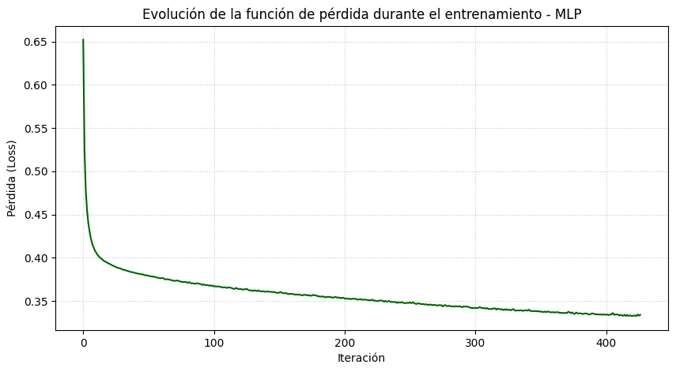

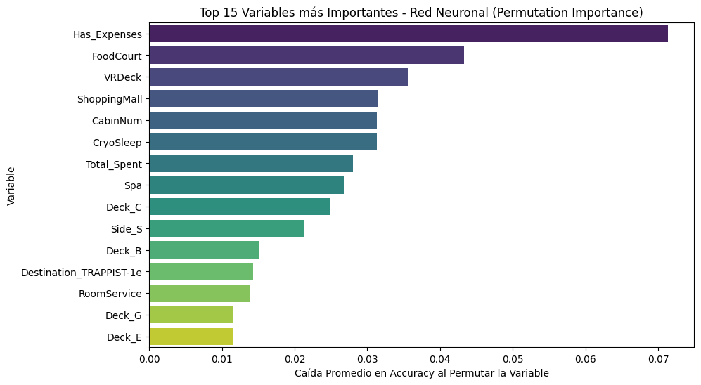

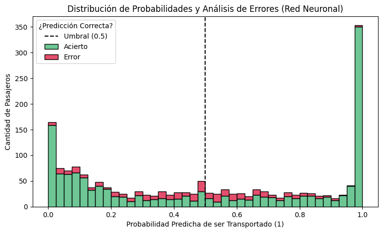

```
--- Análisis de Coherencia ---
El modelo estuvo altamente indeciso en 127 pasajeros del conjunto de prueba.
Estas son predicciones donde la probabilidad de ser transportado fue casi un 'volado' (50/50).

Cómo leer el histograma:
- Los errores (en rojo) agrupados cerca de la línea del 0.5 corresponden a pasajeros ambiguos, donde el modelo prácticamente 'lanzó una moneda'.
- Los errores (en rojo) cerca de los extremos (0.0 o 1.0) son más preocupantes: el modelo estaba muy seguro de su respuesta y aun así se equivocó, lo que suele indicar pasajeros con perfiles atípicos frente al patrón general de los datos.
```

```python
# Escribe tu código aquí

import pandas as pd
import matplotlib.pyplot as plt
import seaborn as sns
from sklearn.inspection import permutation_importance

# Evolución del error durante el entrenamiento
plt.figure(figsize=(10, 5))
plt.plot(mejor_modelo_mlp.loss_curve_, color='darkgreen')
plt.title('Evolución de la función de pérdida durante el entrenamiento - MLP')
plt.xlabel('Iteración')
plt.ylabel('Pérdida (Loss)')
plt.grid(True, linestyle=':', alpha=0.7)
plt.show()

# Importancia de variables (Permutation Importance)
# Usamos "permutation importance": mide cuánto empeora la exactitud del modelo al
# mezclar aleatoriamente los valores de cada variable, una a la vez, en el conjunto de prueba.
resultado_importancia = permutation_importance(
    mejor_modelo_mlp, X_test, y_test,
    n_repeats=10, random_state=42, scoring='accuracy', n_jobs=-1
)

df_importancia_mlp = pd.DataFrame({
    'Variable': X.columns,
    'Importancia': resultado_importancia.importances_mean
})

# Ordenamos de mayor a menor importancia
df_importancia_mlp = df_importancia_mlp.sort_values(by='Importancia', ascending=False)

# Filtramos las 15 variables con mayor impacto
df_top_importancia_mlp = df_importancia_mlp.head(15)

# 3. Visualización (Permutation Importance)
plt.figure(figsize=(10, 6))
sns.barplot(x='Importancia', y='Variable', data=df_top_importancia_mlp, palette='viridis')
plt.title('Top 15 Variables más Importantes - Red Neuronal (Permutation Importance)')
plt.xlabel('Caída Promedio en Accuracy al Permutar la Variable')
plt.ylabel('Variable')
plt.show()

# Análisis de las predicciones dudosas
df_errores_mlp = pd.DataFrame({
    'Clase_Real': y_test,
    'Prediccion': y_pred_test_mlp,
    'Probabilidad': y_prob_test_mlp
})
df_errores_mlp['Es_Correcto'] = df_errores_mlp['Clase_Real'] == df_errores_mlp['Prediccion']

# Casos donde el modelo estuvo muy indeciso (probabilidad entre 0.45 y 0.55)
indecisos_mlp = df_errores_mlp[(df_errores_mlp['Probabilidad'] >= 0.45) & (df_errores_mlp['Probabilidad'] <= 0.55)]

# Visualización: distribución de probabilidades, separando aciertos de errores
plt.figure(figsize=(9, 5))
sns.histplot(data=df_errores_mlp, x='Probabilidad', hue='Es_Correcto',
             multiple='stack', palette={True: 'mediumseagreen', False: 'crimson'}, bins=40)
plt.axvline(x=0.5, color='black', linestyle='--', label='Umbral de Decisión (0.5)')
plt.title('Distribución de Probabilidades y Análisis de Errores (Red Neuronal)')
plt.xlabel('Probabilidad Predicha de ser Transportado (1)')
plt.ylabel('Cantidad de Pasajeros')
plt.legend(title='¿Predicción Correcta?', labels=['Umbral (0.5)', 'Acierto', 'Error'])
plt.show()

print(f"\n--- Análisis de Coherencia ---")
print(f"El modelo estuvo altamente indeciso en {len(indecisos_mlp)} pasajeros del conjunto de prueba.")
print("Estas son predicciones donde la probabilidad de ser transportado fue casi un 'volado' (50/50).")
print("\nCómo leer el histograma:")
print("- Los errores (en rojo) agrupados cerca de la línea del 0.5 corresponden a pasajeros ambiguos, donde el modelo prácticamente 'lanzó una moneda'.")
print("- Los errores (en rojo) cerca de los extremos (0.0 o 1.0) son más preocupantes: el modelo estaba muy seguro de su respuesta y aun así se equivocó, lo que suele indicar pasajeros con perfiles atípicos frente al patrón general de los datos.")
```